# Project 1, Bioinformatics Institute, Statistics and R

Alexandra Gorbonos

6.11.2021

## Description

This project is the part of course “Statistics and R” in BI. The idea of the this project is to practice standard R functions and calculating some stats using data from the Olympic Games for the last 120 years.

## Task 1, Uploading files

Data is divided into several parts, we need to bind them.

```r
read_files <- function(path)
{
  total_path <- paste(getwd(), path, sep='')
  file_list <- list.files(path=total_path)
  dataset <- data.frame()
  print(file_list)
  for (i in 1:length(file_list)){
    temp_data <- read.csv(paste(total_path, file_list[i], sep=""))
    dataset <- rbind(dataset, temp_data)
  }
  dataset
}


dataset <- read_files('/data_folder/')
```

```
##  [1] "athlete_events00.csv" "athlete_events01.csv" "athlete_events02.csv"
##  [4] "athlete_events03.csv" "athlete_events04.csv" "athlete_events05.csv"
##  [7] "athlete_events06.csv" "athlete_events07.csv" "athlete_events08.csv"
## [10] "athlete_events09.csv" "athlete_events10.csv" "athlete_events11.csv"
```

## Task 2, Check data

We can use the command below to explore data:

```r
str(dataset)
```

```
## 'data.frame':    271115 obs. of  15 variables:
##  $ ID    : int  1 2 3 4 5 5 5 5 5 5 ...
##  $ Name  : chr  "A Dijiang" "A Lamusi" "Gunnar Nielsen Aaby" "Edgar Lindenau Aabye" ...
##  $ Sex   : chr  "M" "M" "M" "M" ...
##  $ Age   : int  24 23 24 34 21 21 25 25 27 27 ...
##  $ Height: int  180 170 NA NA 185 185 185 185 185 185 ...
##  $ Weight: num  80 60 NA NA 82 82 82 82 82 82 ...
##  $ Team  : chr  "China" "China" "Denmark" "Denmark/Sweden" ...
##  $ NOC   : chr  "CHN" "CHN" "DEN" "DEN" ...
##  $ Games : chr  "1992 Summer" "2012 Summer" "1920 Summer" "1900 Summer" ...
##  $ Year  : int  1992 2012 1920 1900 1988 1988 1992 1992 1994 1994 ...
##  $ Season: chr  "Summer" "Summer" "Summer" "Summer" ...
##  $ City  : chr  "Barcelona" "London" "Antwerpen" "Paris" ...
##  $ Sport : chr  "Basketball" "Judo" "Football" "Tug-Of-War" ...
##  $ Event : chr  "Basketball Men's Basketball" "Judo Men's Extra-Lightweight" "Football Men's Football" "Tug-Of-War Men's Tug-Of-War" ...
##  $ Medal : chr  NA NA NA "Gold" ...
```

Such variables as ‘Height’, ‘Weight’, ‘Age’ contain NA. To deal with NA in ‘Height’ and ‘Weight’ I decided to replace it with mean value, this solution was chosen to avoid missing large amount of data. In ‘Age’ column just a little part of table was NA, so I dropped it.

```r
dataset_without_NA <- dataset
mean_h <- mean(dataset_without_NA$Height[is.na(dataset_without_NA$Height) == FALSE])
dataset_without_NA$Height[is.na(dataset_without_NA$Height)] <- mean_h

mean_w <- mean(dataset_without_NA$Weight[is.na(dataset_without_NA$Weight) == FALSE])
dataset_without_NA$Weight[is.na(dataset_without_NA$Weight)] <- mean_w

dataset_without_NA <- dataset_without_NA[is.na(dataset_without_NA$Age) == FALSE,]
```

To check data i used:

```r
check_s <- unique(dataset_without_NA$Sex)
print(check_s)
```

```
## [1] "M" "F" "G"
```

On this step I found one more problem with data: one participant has “G” in Sex column, so I googled this person and realized that he is male.

```r
dataset_without_NA$Sex[dataset_without_NA$Sex == 'G'] <- 'M'
```

To find the youngest sportsmen:

```r
M_data <- dataset_without_NA[dataset_without_NA$Sex == 'M',]
M_data[M_data$Age == min(M_data$Age),]
```

```
##           ID               Name Sex Age   Height   Weight
## 142883 71691 Dimitrios Loundras   M  10 175.3398 70.70223
##                                 Team NOC       Games Year Season   City
## 142883 Ethnikos Gymnastikos Syllogos GRE 1896 Summer 1896 Summer Athina
##             Sport                                 Event  Medal
## 142883 Gymnastics Gymnastics Men's Parallel Bars, Teams Bronze
```

```r
F_data <- dataset_without_NA[dataset_without_NA$Sex == 'F',]
F_data[F_data$Age == min(F_data$Age),]
```

```
##            ID                                            Name Sex Age   Height
## 43469   22411                      Magdalena Cecilia Colledge   F  11 152.0000
## 79025   40129                                Luigina Giavotti   F  11 175.3398
## 94059   47618      Sonja Henie (-Topping, -Gardiner, -Onstad)   F  11 155.0000
## 101379  51268                                  Beatrice Hutiu   F  11 151.0000
## 102917  52070                                    Etsuko Inada   F  11 175.3398
## 140651  70616                                      Liu Luyang   F  11 175.3398
## 152799  76675                               Marcelle Matthews   F  11 175.3398
## 237141 118925 Megan Olwen Devenish Taylor (-Mandeville-Ellis)   F  11 157.0000
## 252230 126307                                    Liana Vicens   F  11 158.0000
## 252231 126307                                    Liana Vicens   F  11 158.0000
## 252232 126307                                    Liana Vicens   F  11 158.0000
## 252233 126307                                    Liana Vicens   F  11 158.0000
##          Weight          Team NOC       Games Year Season
## 43469  70.70223 Great Britain GBR 1932 Winter 1932 Winter
```

[output cut: 37 more lines]

## Task 4, Count mean and standart deviation for males and females height

```r
mean(M_data$Height)
```

```
## [1] 178.045
```

```r
sd(M_data$Height)
```

```
## [1] 8.302628
```

```r
mean(F_data$Height)
```

```
## [1] 168.528
```

```r
sd(F_data$Height)
```

```
## [1] 8.661032
```

## Task 5, Count mean and standart deviation for females who played tennis in 2000

```r
mean(F_data$Height[(F_data$Year == 2000) & (F_data$Sport == 'Tennis')])
```

```
## [1] 171.8202
```

```r
sd(F_data$Height[(F_data$Year == 2000) & (F_data$Sport == 'Tennis')])
```

```
## [1] 6.440546
```

## Task 6, Find the player with the heaviest weight in 2006, define the sport he participated in

```r
weights_2006 <- M_data$Weight[(M_data$Year == 2006)]
weights_2006 <- weights_2006[is.na(weights_2006) == FALSE]

M_data[(M_data$Weight == max(weights_2006)) & (M_data$Year == 2006), ]
```

```
##        ID              Name Sex Age Height Weight    Team NOC       Games Year
## 8103 4476 Patrick R. Antaki   M  41    185    127 Lebanon LIB 2006 Winter 2006
##      Season   City    Sport                   Event Medal
## 8103 Winter Torino Skeleton Skeleton Men's Skeleton  <NA>
```

## Task 7, The number of golden medals won by females on the period from 1980 to 2010

```r
F_data_medal <- F_data[is.na(F_data$Medal) == FALSE,]
F_data_medal <- F_data_medal[F_data_medal$Medal == 'Gold',]
F_data_medal <- F_data_medal[(F_data_medal$Year >= 1980) & (F_data_medal$Year <= 2010),]
sum((F_data_medal$Year >= 1980) & (F_data_medal$Year <= 2010))
```

```
## [1] 2249
```

## Task 8, How many times did John Aalberg participat in Olympic games in different years

```r
data_years <- dataset_without_NA[dataset_without_NA$Name == 'John Aalberg',]
years <- unique(dataset_without_NA$Year[dataset_without_NA$Name == 'John Aalberg'])
for (i in 1:length(years)){
  print(c(years[i], sum(data_years$Year == years[i])))
}
```

```
## [1] 1992    4
## [1] 1994    4
```

## Task 9, Count the numper of participants in different age groups

Possible age groups: [15-25), [25-35), [35-45), [45-55].

```r
dataset_without_NA_2008 <-  dataset_without_NA[dataset_without_NA$Year == 2008,]

data_15_25 <- dataset_without_NA_2008[dataset_without_NA_2008$Age >= 15 & dataset_without_NA_2008$Age < 25,]
print(length(unique(data_15_25$Name)))
```

```
## [1] 4784
```

```r
data_25_35 <- dataset_without_NA_2008[dataset_without_NA_2008$Age >= 25 & dataset_without_NA_2008$Age < 35,]
print(length(unique(data_25_35$Name)))
```

```
## [1] 5377
```

```r
data_35_45 <- dataset_without_NA_2008[dataset_without_NA_2008$Age >= 35 & dataset_without_NA_2008$Age < 45,]
print(length(unique(data_35_45$Name)))
```

```
## [1] 631
```

```r
data_45_55 <- dataset_without_NA_2008[dataset_without_NA_2008$Age >= 45 & dataset_without_NA_2008$Age <= 55,]
print(length(unique(data_45_55$Name)))
```

```
## [1] 79
```

## Task10, The differense in number of sports between 1994 and 2002

```r
dataset_without_NA_2002 <-  dataset_without_NA[dataset_without_NA$Year == 2002,]
dataset_without_NA_1994 <-  dataset_without_NA[dataset_without_NA$Year == 1994,]

difference <- length(unique(dataset_without_NA_2002$Sport)) - length(unique(dataset_without_NA_1994$Sport))
print(difference)
```

```
## [1] 3
```

## Task11, Top 3 countries for each kind of medal (Gold/Silver/Bronze)

Separately for the winter and summer olympics

Summer:

```r
country_list <- c()
medals_amount <- c()
Summer <- dataset_without_NA[dataset_without_NA$Season == 'Summer',]
Countries <- unique(Summer$Team)
Summer <- Summer[!is.na(Summer$Medal), ]
for (country in Countries){

  country_list <- c(country_list, country)
  medals_amount <- c(medals_amount, sum(Summer$Team == country & Summer$Medal == 'Gold'))
}
summer_gold <- data.frame(country_list, medals_amount)
summer_gold <- summer_gold[order(-medals_amount),]
head(summer_gold, 3)
```

```
##     country_list medals_amount
## 27 United States          2331
## 28  Soviet Union           830
## 74       Germany           561
```

```r
country_list <- c()
medals_amount <- c()
Summer <- dataset_without_NA[dataset_without_NA$Season == 'Summer',]
Countries <- unique(Summer$Team)
Summer <- Summer[!is.na(Summer$Medal), ]
for (country in Countries){

  country_list <- c(country_list, country)
  medals_amount <- c(medals_amount, sum(Summer$Team == country & Summer$Medal == 'Silver'))
}
summer_silver <- data.frame(country_list, medals_amount)
summer_silver <- summer_silver[order(-medals_amount),]
head(summer_silver, 3)
```

```
##     country_list medals_amount
## 27 United States          1232
## 28  Soviet Union           635
## 87 Great Britain           554
```

```r
country_list <- c()
medals_amount <- c()
Summer <- dataset_without_NA[dataset_without_NA$Season == 'Summer',]
Countries <- unique(Summer$Team)
Summer <- Summer[!is.na(Summer$Medal), ]
for (country in Countries){
  country_list <- c(country_list, country)
  medals_amount <- c(medals_amount, sum(Summer$Team == country & Summer$Medal == 'Bronze'))
}
summer_bronze <- data.frame(country_list, medals_amount)
summer_bronze <- summer_bronze[order(-medals_amount),]
head(summer_bronze, 3)
```

```
##     country_list medals_amount
## 27 United States          1109
## 74       Germany           606
## 28  Soviet Union           596
```

Winter:

```r
country_list <- c()
medals_amount <- c()
Winter <- dataset_without_NA[dataset_without_NA$Season == 'Winter',]
Countries <- unique(Winter$Team)
Winter <- Winter[!is.na(Winter$Medal), ]
for (country in Countries){
  country_list <- c(country_list, country)
  medals_amount <- c(medals_amount, sum(Winter$Team == country & Winter$Medal == 'Gold'))
}
winter_gold <- data.frame(country_list, medals_amount)
winter_gold <- winter_gold[order(-medals_amount),]
head(winter_gold, 3)
```

```
##    country_list medals_amount
## 11       Canada           289
## 33 Soviet Union           228
## 4        Norway           151
```

```r
country_list <- c()
medals_amount <- c()
Winter <- dataset_without_NA[dataset_without_NA$Season == 'Winter',]
Countries <- unique(Winter$Team)
Winter <- Winter[!is.na(Winter$Medal), ]
for (country in Countries){
  country_list <- c(country_list, country)
  medals_amount <- c(medals_amount, sum(Winter$Team == country & Winter$Medal == 'Silver'))
}
winter_silver <- data.frame(country_list, medals_amount)
winter_silver <- winter_silver[order(-medals_amount),]
head(winter_silver, 3)
```

```
##     country_list medals_amount
## 2  United States           271
## 11        Canada           189
## 4         Norway           165
```

```r
country_list <- c()
medals_amount <- c()
Countries <- unique(Winter$Team)
Winter <- Winter[!is.na(Winter$Medal), ]
for (country in Countries){
  country_list <- c(country_list, country)
  medals_amount <- c(medals_amount, sum((Winter$Team == country) & (Winter$Medal == 'Bronze')))
  print(c(country, sum((Winter$Team == country) & (Winter$Medal == 'Bronze'))))
}
```

```
## [1] "Finland" "215"
## [1] "Norway" "127"
## [1] "United States" "121"
## [1] "Japan" "24"
## [1] "Canada" "97"
## [1] "Sweden" "177"
## [1] "Russia" "71"
## [1] "Switzerland" "97"
## [1] "Soviet Union" "81"
## [1] "Germany" "68"
## [1] "Switzerland-1" "30"
## [1] "Switzerland-2" "2"
## [1] "Great Britain" "31"
## [1] "Germany-2" "10"
## [1] "United States-1" "24"
```

[output cut: 60 more lines]

```r
winter_bronze <- data.frame(country_list, medals_amount)
winter_bronze <- winter_bronze[order(-medals_amount),]
head(winter_bronze, 3)
```

```
##   country_list medals_amount
## 1      Finland           215
## 6       Sweden           177
## 2       Norway           127
```

## Task 12, Height_z_scores

```r
dataset_without_NA$Height_z_scores <- scale(dataset_without_NA$Height)
dataset_without_NA
```

[output not shown]

[output cut: 31236 more lines]

## Task13, Min/Max normalization

```r
min_max_function <- function(x, na.rm = TRUE){
  return((x- min(x)) / (max(x)-min(x)))
}
dataset_without_NA$Height_min_max_scaled <- min_max_function(dataset_without_NA$Height)
```

## Task 14, Comparing Height, Weight and Age of males and females in winter Olympiad Games

#### Height

Normality test:

```r
F_data_winter <- F_data[F_data$Season == 'Winter',]
M_data_winter <- M_data[M_data$Season == 'Winter',]
shapiro.test(F_data_winter$Height[0:5000])
```

```
##
##  Shapiro-Wilk normality test
##
## data:  F_data_winter$Height[0:5000]
## W = 0.98539, p-value < 2.2e-16
```

```r
shapiro.test(M_data_winter$Height[0:5000])
```

```
##
##  Shapiro-Wilk normality test
##
## data:  M_data_winter$Height[0:5000]
## W = 0.97007, p-value < 2.2e-16
```

Boxplot:

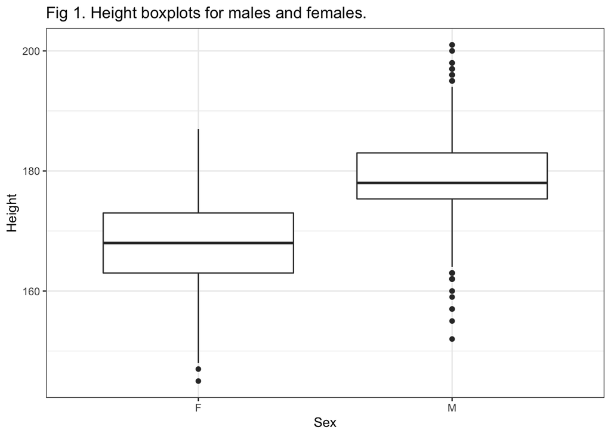

```r
FM_Height_boxplot <- ggplot(Winter, aes(x = as.factor(Sex), y=Height, group=Sex)) +
  geom_boxplot() +
  scale_x_discrete(name = "Sex") +
  labs(title = "Fig 1. Height boxplots for males and females.") +
  theme_bw()
FM_Height_boxplot
```

H0: Males and Females have equal height. H1: Males and Females have different height.

```r
t.test(x=F_data_winter$Height, y=M_data_winter$Height, alternative = c("two.sided"))
```

```
##
##  Welch Two Sample t-test
##
## data:  F_data_winter$Height and M_data_winter$Height
## t = -173.04, df = 28035, p-value < 2.2e-16
## alternative hypothesis: true difference in means is not equal to 0
## 95 percent confidence interval:
##  -10.70759 -10.46774
## sample estimates:
## mean of x mean of y
##  167.4344  178.0221
```

One more t test: H0: Males and Females have equal height. H1: Males are highter than females.

```r
t.test(x=F_data_winter$Height, y=M_data_winter$Height, alternative = c("less"))
```

```
##
##  Welch Two Sample t-test
##
## data:  F_data_winter$Height and M_data_winter$Height
## t = -173.04, df = 28035, p-value < 2.2e-16
## alternative hypothesis: true difference in means is less than 0
## 95 percent confidence interval:
##       -Inf -10.48702
## sample estimates:
## mean of x mean of y
##  167.4344  178.0221
```

#### Weight

Normality test:

```r
shapiro.test(F_data_winter$Weight[0:5000])
```

```
##
##  Shapiro-Wilk normality test
##
## data:  F_data_winter$Weight[0:5000]
## W = 0.98312, p-value < 2.2e-16
```

```r
shapiro.test(M_data_winter$Weight[0:5000])
```

```
##
##  Shapiro-Wilk normality test
##
## data:  M_data_winter$Weight[0:5000]
## W = 0.92602, p-value < 2.2e-16
```

Boxplot:

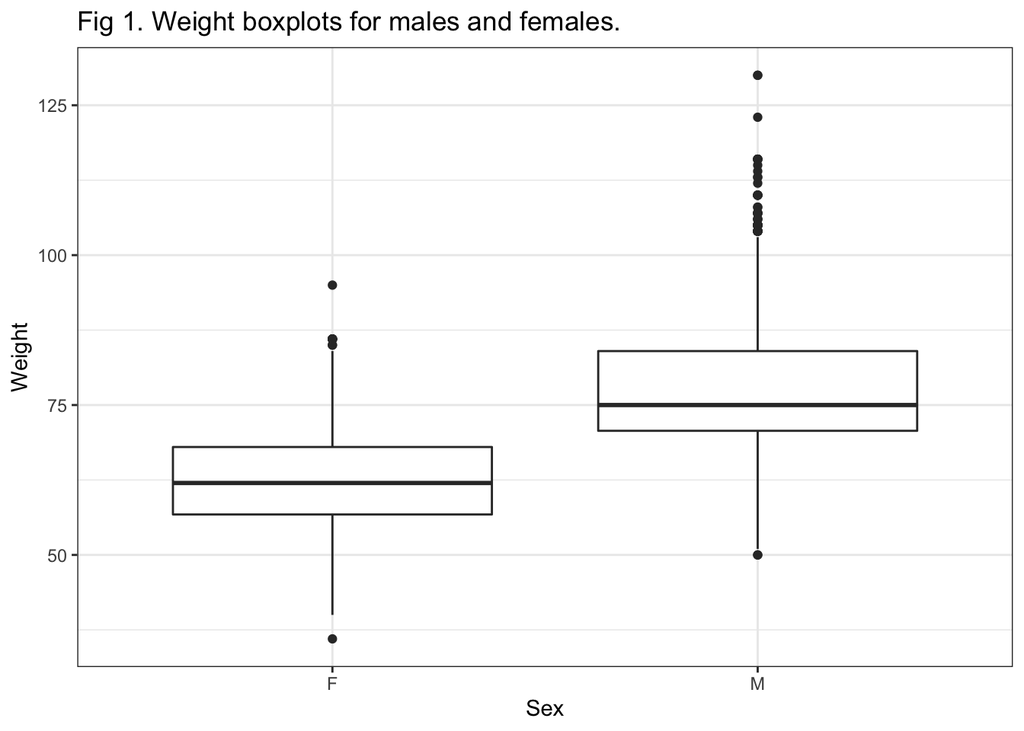

```r
FM_Weight_boxplot <- ggplot(Winter, aes(x = as.factor(Sex), y=Weight, group=Sex)) +
  geom_boxplot() +
  scale_x_discrete(name = "Sex") +
  labs(title = "Fig 1. Weight boxplots for males and females.") +
  theme_bw()
FM_Weight_boxplot
```

H0: Males and Females have equal weight. H1: Males and Females have different weight.

```r
t.test(x=F_data_winter$Weight, y=M_data_winter$Weight, alternative = c("two.sided"))
```

```
##
##  Welch Two Sample t-test
##
## data:  F_data_winter$Weight and M_data_winter$Weight
## t = -176.41, df = 36128, p-value < 2.2e-16
## alternative hypothesis: true difference in means is not equal to 0
## 95 percent confidence interval:
##  -14.30522 -13.99083
## sample estimates:
## mean of x mean of y
##  61.01849  75.16651
```

One more t test: H0: Males and Females have equal weight. H1: Males have bigger weight than females.

```r
t.test(x=F_data_winter$Weight, y=M_data_winter$Weight, alternative = c("less"))
```

```
##
##  Welch Two Sample t-test
##
## data:  F_data_winter$Weight and M_data_winter$Weight
## t = -176.41, df = 36128, p-value < 2.2e-16
## alternative hypothesis: true difference in means is less than 0
## 95 percent confidence interval:
##      -Inf -14.0161
## sample estimates:
## mean of x mean of y
##  61.01849  75.16651
```

#### Age

Normality test:

```r
shapiro.test(F_data_winter$Age[0:5000])
```

```
##
##  Shapiro-Wilk normality test
##
## data:  F_data_winter$Age[0:5000]
## W = 0.98107, p-value < 2.2e-16
```

```r
shapiro.test(M_data_winter$Age[0:5000])
```

```
##
##  Shapiro-Wilk normality test
##
## data:  M_data_winter$Age[0:5000]
## W = 0.9629, p-value < 2.2e-16
```

Boxplot:

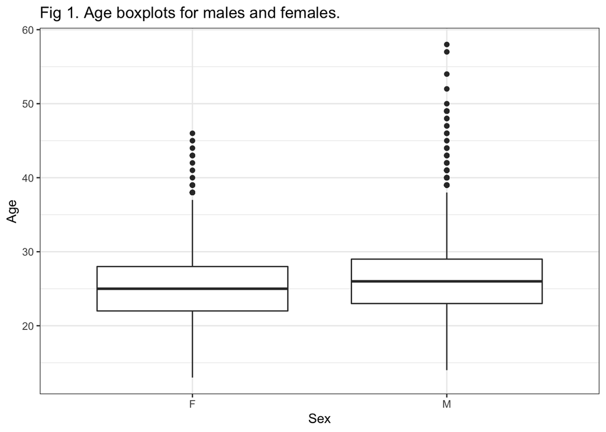

```r
FM_Age_boxplot <- ggplot(Winter, aes(x = as.factor(Sex), y=Age, group=Sex)) +
  geom_boxplot() +
  scale_x_discrete(name = "Sex") +
  labs(title = "Fig 1. Age boxplots for males and females.") +
  theme_bw()
FM_Age_boxplot
```

H0: Males and Females have the same age. H1: Males and Females have different ages.

```r
t.test(x=F_data_winter$Age, y=M_data_winter$Age, alternative = c("two.sided"))
```

```
##
##  Welch Two Sample t-test
##
## data:  F_data_winter$Age and M_data_winter$Age
## t = -32.239, df = 29455, p-value < 2.2e-16
## alternative hypothesis: true difference in means is not equal to 0
## 95 percent confidence interval:
##  -1.580799 -1.399600
## sample estimates:
## mean of x mean of y
##   24.0142   25.5044
```

One more t test: H0: Males and Females have the same age. H1: Males are older than females.

```r
t.test(x=F_data_winter$Age, y=M_data_winter$Age, alternative = c("less"))
```

```
##
##  Welch Two Sample t-test
##
## data:  F_data_winter$Age and M_data_winter$Age
## t = -32.239, df = 29455, p-value < 2.2e-16
## alternative hypothesis: true difference in means is less than 0
## 95 percent confidence interval:
##       -Inf -1.414166
## sample estimates:
## mean of x mean of y
##   24.0142   25.5044
```